# Bellabeat

meiyin

2022-12-01

## Background

Urška Sršen and Sando Mur founded Bellabeat, a high-tech company that manufactures health-focused smart products. Sršen used her background as an artist to develop beautifully designed technology that informs and inspires women around the world. Collecting data on activity, sleep, stress, and reproductive health has allowed Bellabeat to empower women with knowledge about their own health and habits. Since it was founded in 2013, Bellabeat has grown rapidly and quickly positioned itself as a tech-driven wellness company for women.

## Step 1: Ask

## Task

To analyse non-Bellabeat smart devices and its usage by consumers in order to apply these insights on Bellabeat products to drive sales.

### Key stakeholders

*Urška Sršen: Bellabeat’s cofounder and Chief Creative Officer* Sando Mur: Mathematician and Bellabeat’s co-founder

### Questions to explore:

1. What are some trends in smart device usage?
2. How could these trends apply to Bellabeat customers?
3. How could these trends help influence Bellabeat marketing strategy?

## Step 2: Prepare

## About dataset

This dataset is downloaded and uploaded to RStudio. It was then analyse using the ROCC approach:

- Reliability: LOW. Dataset is collected from 30 Fitbit users but their gender is unknown.
- Originality: LOW. Third party collected the data; Amazon Mechanical Turk.
- Comprehensive: MEDIUM. It contains a number of information such as sleep activity, daily activity and their weight. However, it does not contain information on one’s gender, age and their health status.
- Current: LOW. This dataset was collected in 2016 and it is considered old as people’s fitness level may change over time.
- Cited: LOW. It does state that the dataset was from Amazon Mechanical Turk; however, there is no link or information regarding this.

### Install and load packages

```r
#install.packages(c("tidyverse", "lubridate", "tidyr", "skimr", "janitor", "dplyr", "ggplot2"))
```

```r
#lapply(c("tidyverse", "lmtest", "skimr", "janitor", "lubridate", "tidyr", "dplyr", "ggplot2"), require, character.only = TRUE)
```

```r
library(tidyverse)
library(lubridate)
library(tidyr)
library(skimr)
library(janitor)
```

```r
library(dplyr)
library(ggplot2)
```

# Step 3: Process

## Importing datasets

```r
activity<- read.csv("archive/Fitabase/dailyActivity_merged.csv")
```

```r
sleep<- read.csv("archive/Fitabase/sleepDay_merged.csv")
```

```r
weight<- read.csv("archive/Fitabase/weightLogInfo_merged.csv")
```

## Clean and process data

```r
head(activity)
```

```
##           Id ActivityDate TotalSteps TotalDistance TrackerDistance
## 1 1503960366    4/12/2016      13162          8.50            8.50
## 2 1503960366    4/13/2016      10735          6.97            6.97
## 3 1503960366    4/14/2016      10460          6.74            6.74
## 4 1503960366    4/15/2016       9762          6.28            6.28
## 5 1503960366    4/16/2016      12669          8.16            8.16
## 6 1503960366    4/17/2016       9705          6.48            6.48
##   LoggedActivitiesDistance VeryActiveDistance ModeratelyActiveDistance
## 1                        0               1.88                     0.55
## 2                        0               1.57                     0.69
## 3                        0               2.44                     0.40
## 4                        0               2.14                     1.26
## 5                        0               2.71                     0.41
## 6                        0               3.19                     0.78
##   LightActiveDistance SedentaryActiveDistance VeryActiveMinutes
## 1                6.06                       0                25
## 2                4.71                       0                21
## 3                3.91                       0                30
## 4                2.83                       0                29
## 5                5.04                       0                36
## 6                2.51                       0                38
##   FairlyActiveMinutes LightlyActiveMinutes SedentaryMinutes Calories
## 1                  13                  328              728     1985
## 2                  19                  217              776     1797
## 3                  11                  181             1218     1776
## 4                  34                  209              726     1745
## 5                  10                  221              773     1863
## 6                  20                  164              539     1728
```

```r
head(weight)
```

```
##           Id                  Date WeightKg WeightPounds Fat   BMI
## 1 1503960366  5/2/2016 11:59:59 PM     52.6     115.9631  22 22.65
## 2 1503960366  5/3/2016 11:59:59 PM     52.6     115.9631  NA 22.65
## 3 1927972279  4/13/2016 1:08:52 AM    133.5     294.3171  NA 47.54
## 4 2873212765 4/21/2016 11:59:59 PM     56.7     125.0021  NA 21.45
## 5 2873212765 5/12/2016 11:59:59 PM     57.3     126.3249  NA 21.69
## 6 4319703577 4/17/2016 11:59:59 PM     72.4     159.6147  25 27.45
##   IsManualReport        LogId
## 1           True 1.462234e+12
## 2           True 1.462320e+12
## 3          False 1.460510e+12
## 4           True 1.461283e+12
## 5           True 1.463098e+12
## 6           True 1.460938e+12
```

```r
head(sleep)
```

```
##           Id              SleepDay TotalSleepRecords TotalMinutesAsleep
## 1 1503960366 4/12/2016 12:00:00 AM                 1                327
## 2 1503960366 4/13/2016 12:00:00 AM                 2                384
## 3 1503960366 4/15/2016 12:00:00 AM                 1                412
## 4 1503960366 4/16/2016 12:00:00 AM                 2                340
## 5 1503960366 4/17/2016 12:00:00 AM                 1                700
## 6 1503960366 4/19/2016 12:00:00 AM                 1                304
##   TotalTimeInBed
## 1            346
## 2            407
## 3            442
## 4            367
## 5            712
## 6            320
```

```r
str(activity)
```

```
## 'data.frame':    940 obs. of  15 variables:
##  $ Id                      : num  1.5e+09 1.5e+09 1.5e+09 1.5e+09 1.5e+09 ...
##  $ ActivityDate            : chr  "4/12/2016" "4/13/2016" "4/14/2016" "4/15/2016" ...
##  $ TotalSteps              : int  13162 10735 10460 9762 12669 9705 13019 15506 10544 9819 ...
##  $ TotalDistance           : num  8.5 6.97 6.74 6.28 8.16 ...
##  $ TrackerDistance         : num  8.5 6.97 6.74 6.28 8.16 ...
##  $ LoggedActivitiesDistance: num  0 0 0 0 0 0 0 0 0 0 ...
##  $ VeryActiveDistance      : num  1.88 1.57 2.44 2.14 2.71 ...
##  $ ModeratelyActiveDistance: num  0.55 0.69 0.4 1.26 0.41 ...
##  $ LightActiveDistance     : num  6.06 4.71 3.91 2.83 5.04 ...
##  $ SedentaryActiveDistance : num  0 0 0 0 0 0 0 0 0 0 ...
##  $ VeryActiveMinutes       : int  25 21 30 29 36 38 42 50 28 19 ...
##  $ FairlyActiveMinutes     : int  13 19 11 34 10 20 16 31 12 8 ...
##  $ LightlyActiveMinutes    : int  328 217 181 209 221 164 233 264 205 211 ...
##  $ SedentaryMinutes        : int  728 776 1218 726 773 539 1149 775 818 838 ...
##  $ Calories                : int  1985 1797 1776 1745 1863 1728 1921 2035 1786 1775 ...
```

```r
str(weight)
```

```
## 'data.frame':    67 obs. of  8 variables:
##  $ Id            : num  1.50e+09 1.50e+09 1.93e+09 2.87e+09 2.87e+09 ...
##  $ Date          : chr  "5/2/2016 11:59:59 PM" "5/3/2016 11:59:59 PM" "4/13/2016 1:08:52 AM" "4/21/2016 11:59:59 PM" ...
##  $ WeightKg      : num  52.6 52.6 133.5 56.7 57.3 ...
##  $ WeightPounds  : num  116 116 294 125 126 ...
##  $ Fat           : int  22 NA NA NA NA 25 NA NA NA NA ...
##  $ BMI           : num  22.6 22.6 47.5 21.5 21.7 ...
##  $ IsManualReport: chr  "True" "True" "False" "True" ...
##  $ LogId         : num  1.46e+12 1.46e+12 1.46e+12 1.46e+12 1.46e+12 ...
```

```r
str(sleep)
```

```
## 'data.frame':    413 obs. of  5 variables:
##  $ Id                : num  1.5e+09 1.5e+09 1.5e+09 1.5e+09 1.5e+09 ...
##  $ SleepDay          : chr  "4/12/2016 12:00:00 AM" "4/13/2016 12:00:00 AM" "4/15/2016 12:00:00 AM" "4/16/2016 12:00:00 AM" ...
##  $ TotalSleepRecords : int  1 2 1 2 1 1 1 1 1 1 ...
##  $ TotalMinutesAsleep: int  327 384 412 340 700 304 360 325 361 430 ...
##  $ TotalTimeInBed    : int  346 407 442 367 712 320 377 364 384 449 ...
```

```r
activity$ActivityDate<-as.Date(activity$ActivityDate, format="%m/%d/%Y")
activity$Date<- as.Date(activity$ActivityDate, format="%m/%d/%Y")
```

```r
weight$Date<-as.POSIXct(weight$Date, format="%m/%d/%Y %I:%M:%S %p", tz=Sys.timezone())
weight$Date_2 <- as.Date(weight$Date, format = "%m/%d/%Y")
weight$Time <- format(as.POSIXct(weight$Date), format = "%H:%M:%S")
weight$Month <- format(weight$Date, format = "%B")
```

```r
sleep$Date<-as.Date(sleep$SleepDay, format="%m/%d/%Y")
sleep$SleepDay<-as.POSIXct(sleep$SleepDay, format="%m/%d/%Y %I:%M:%S %p", tz=Sys.timezone())
```

```r
apply(activity, 2, function(x) any(is.na(x)))
```

```
##                       Id             ActivityDate               TotalSteps
##                    FALSE                    FALSE                    FALSE
##            TotalDistance          TrackerDistance LoggedActivitiesDistance
##                    FALSE                    FALSE                    FALSE
##       VeryActiveDistance ModeratelyActiveDistance      LightActiveDistance
##                    FALSE                    FALSE                    FALSE
##  SedentaryActiveDistance        VeryActiveMinutes      FairlyActiveMinutes
##                    FALSE                    FALSE                    FALSE
##     LightlyActiveMinutes         SedentaryMinutes                 Calories
##                    FALSE                    FALSE                    FALSE
##                     Date
##                    FALSE
```

```r
apply(sleep, 2, function(x) any(is.na(x)))
```

```
##                 Id           SleepDay  TotalSleepRecords TotalMinutesAsleep
##              FALSE              FALSE              FALSE              FALSE
##     TotalTimeInBed               Date
##              FALSE              FALSE
```

There are no null values for sleep dataset.

```r
apply(weight, 2, function(x) any(is.na(x)))
```

```
##             Id           Date       WeightKg   WeightPounds            Fat
##          FALSE          FALSE          FALSE          FALSE           TRUE
##            BMI IsManualReport          LogId         Date_2           Time
##          FALSE          FALSE          FALSE          FALSE          FALSE
##          Month
##          FALSE
```

There are null values for weight dataset which is Fat.

### Clean the columns accordingly

```r
activity<-clean_names(activity)
```

```r
sleep <- clean_names(sleep)
```

```r
weight <- clean_names(weight) %>%
  na.omit(weight)
```

### Check again to see if there are any null values left

```r
apply(weight, 2, function(x) any(is.na(x)))
```

```
##               id             date        weight_kg    weight_pounds
##            FALSE            FALSE            FALSE            FALSE
##              fat              bmi is_manual_report           log_id
##            FALSE            FALSE            FALSE            FALSE
##           date_2             time            month
##            FALSE            FALSE            FALSE
```

# Step 4: Analyse

## Explore data

```r
n_distinct(activity$id)
```

```
## [1] 33
```

```r
n_distinct(sleep$id)
```

```
## [1] 24
```

```r
n_distinct(weight$id)
```

```
## [1] 2
```

There are 33 participants in the activity dataset, 24 participants in the sleep datasets and 2 participants in the weight dataset. Only 2 participants in the weight dataset; therefore, more data is required in order to make any recommendations or conclusions that is concrete and this dataset will not be used for further analysis.

```r
# activity
activity %>%
  select(total_steps, total_distance, sedentary_minutes, calories) %>%
summary()
```

```
##   total_steps    total_distance   sedentary_minutes    calories
##  Min.   :    0   Min.   : 0.000   Min.   :   0.0    Min.   :   0
##  1st Qu.: 3790   1st Qu.: 2.620   1st Qu.: 729.8    1st Qu.:1828
##  Median : 7406   Median : 5.245   Median :1057.5    Median :2134
##  Mean   : 7638   Mean   : 5.490   Mean   : 991.2    Mean   :2304
##  3rd Qu.:10727   3rd Qu.: 7.713   3rd Qu.:1229.5    3rd Qu.:2793
##  Max.   :36019   Max.   :28.030   Max.   :1440.0    Max.   :4900
```

```r
# explore active distance per minutes in activity
activity %>%
  select(very_active_minutes, fairly_active_minutes, lightly_active_minutes) %>%
summary()
```

```
##  very_active_minutes fairly_active_minutes lightly_active_minutes
##  Min.   :  0.00      Min.   :  0.00        Min.   :  0.0
##  1st Qu.:  0.00      1st Qu.:  0.00        1st Qu.:127.0
##  Median :  4.00      Median :  6.00        Median :199.0
##  Mean   : 21.16      Mean   : 13.56        Mean   :192.8
##  3rd Qu.: 32.00      3rd Qu.: 19.00        3rd Qu.:264.0
##  Max.   :210.00      Max.   :143.00        Max.   :518.0
```

```r
# sleep
sleep %>%
  select(total_sleep_records, total_minutes_asleep, total_time_in_bed) %>%
summary()
```

```
##  total_sleep_records total_minutes_asleep total_time_in_bed
##  Min.   :1.000       Min.   : 58.0        Min.   : 61.0
##  1st Qu.:1.000       1st Qu.:361.0        1st Qu.:403.0
##  Median :1.000       Median :433.0        Median :463.0
##  Mean   :1.119       Mean   :419.5        Mean   :458.6
##  3rd Qu.:1.000       3rd Qu.:490.0        3rd Qu.:526.0
##  Max.   :3.000       Max.   :796.0        Max.   :961.0
```

```r
# weight
weight %>%
  select(weight_kg, bmi) %>%
summary()
```

```
##    weight_kg          bmi
##  Min.   :52.60   Min.   :22.65
##  1st Qu.:57.55   1st Qu.:23.85
##  Median :62.50   Median :25.05
##  Mean   :62.50   Mean   :25.05
##  3rd Qu.:67.45   3rd Qu.:26.25
##  Max.   :72.40   Max.   :27.45
```

### Summary

- The average sedentary time is 991.2 minutes which is around 16.5 hours. This has to be reduced as it can have a number of negative effects to the health such as obesity [Mayo Clinic-Risks of being sedentary](https://www.mayoclinic.org/healthy-lifestyle/adult-health/expert-answers/sitting/faq-20058005)
- Majority of the participants fall under the lightly active group.
- The average number of steps per day is 7638. According to CDC, the recommended steps per day is 10,000.
- On average, people sleep for 7 hours.

## Merge data

```r
activity_sleep <- merge(activity, sleep, by= c("id", "date"))
head(activity_sleep)
```

```
##           id       date activity_date total_steps total_distance
## 1 1503960366 2016-04-12    2016-04-12       13162           8.50
## 2 1503960366 2016-04-13    2016-04-13       10735           6.97
## 3 1503960366 2016-04-15    2016-04-15        9762           6.28
## 4 1503960366 2016-04-16    2016-04-16       12669           8.16
## 5 1503960366 2016-04-17    2016-04-17        9705           6.48
## 6 1503960366 2016-04-19    2016-04-19       15506           9.88
##   tracker_distance logged_activities_distance very_active_distance
## 1             8.50                          0                 1.88
## 2             6.97                          0                 1.57
## 3             6.28                          0                 2.14
## 4             8.16                          0                 2.71
## 5             6.48                          0                 3.19
## 6             9.88                          0                 3.53
##   moderately_active_distance light_active_distance sedentary_active_distance
```

[output cut: 27 more lines]

# Step 5: Share

## Visualisation + Exploration

### Total Steps vs Calories

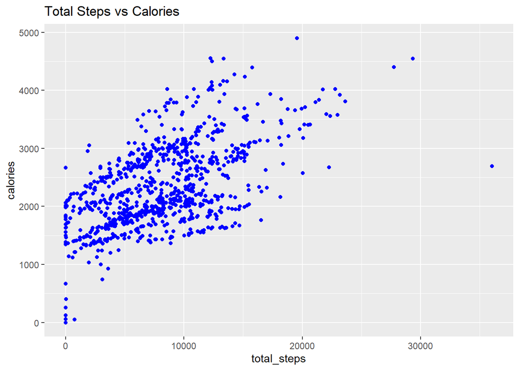

```r
ggplot(data = activity) + aes(x = total_steps, y=calories) + labs(title = "Total Steps vs Calories") + geom_point(color = "blue")
```

```r
cor(activity$total_steps, activity$calories)
```

```
## [1] 0.5915681
```

There is a moderate positive correlation between the number of steps and calories. This indicates that the more steps the participants take, the more calories they burn.

### Time Asleep vs Time in Bed

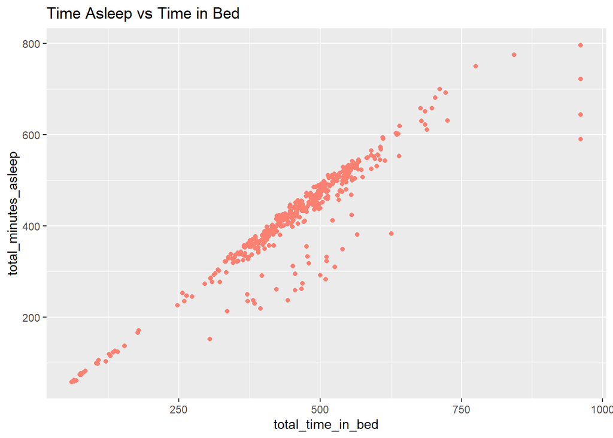

```r
ggplot(data = sleep) + aes(x = total_time_in_bed, y=total_minutes_asleep) + labs(title = "Time Asleep vs Time in Bed") + geom_point(color = "salmon")
```

```r
cor(sleep$total_time_in_bed, sleep$total_minutes_asleep)
```

```
## [1] 0.9304575
```

We can clearly see that there is a high positive correlation between time spent in bed and and time spent sleeping.

### Sleep Duration vs Sedentary Time

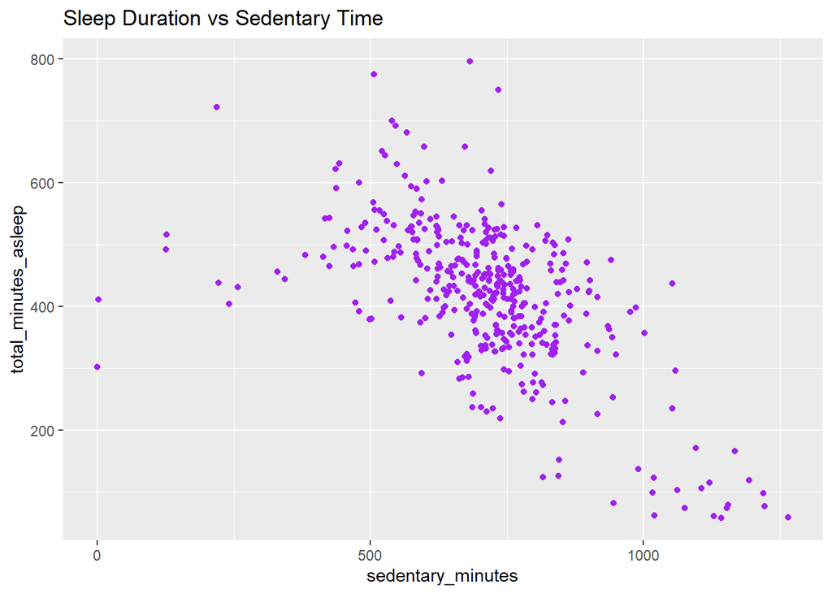

```r
ggplot(data = activity_sleep) + aes(x = sedentary_minutes, y=total_minutes_asleep) + labs(title = "Sleep Duration vs Sedentary Time") + geom_point(color = "purple")
```

```r
cor(activity_sleep$sedentary_minutes, activity_sleep$total_minutes_asleep)
```

```
## [1] -0.599394
```

There is a moderate negative correlation between sleep duration and sedentary time. This means that when a person is less active, they will have a shorter sleep duration.

### Which day are participants more active?

```r
activity_sleep <- mutate(activity_sleep,
                    day = wday(date, label = TRUE))

summarised_activity_sleep <- activity_sleep %>%
  group_by(day) %>%
  summarise(AvgDailySteps = mean(total_steps),
            AvgAsleepMinutes = mean(total_minutes_asleep),
            AvgAwakeTimeInBed = mean(total_time_in_bed),
            AvgSedentaryMinutes = mean(sedentary_minutes),
            AvgLightlyActiveMinutes = mean(lightly_active_minutes),
            AvgFairlyActiveMinutes = mean(fairly_active_minutes),
            AvgVeryActiveMinutes = mean(very_active_minutes),
            AvgCalories = mean(calories))

head(summarised_activity_sleep)
```

```
## # A tibble: 6 × 9
##   day   AvgDailySteps AvgAslee…¹ AvgAw…² AvgSe…³ AvgLi…⁴ AvgFa…⁵ AvgVe…⁶ AvgCa…⁷
##   <ord>         <dbl>      <dbl>   <dbl>   <dbl>   <dbl>   <dbl>   <dbl>   <dbl>
## 1 Sun           7298.       453.    504.    688.    200.    16.8    22.1   2277.
## 2 Mon           9340.       419.    456.    718.    221.    19.0    32.6   2465.
## 3 Tue           9183.       405.    443.    740.    217.    20.0    30.6   2496.
## 4 Wed           8023.       435.    470.    714.    208.    16.7    21.3   2378.
## 5 Thu           8205.       402.    436.    701.    203.    16.2    22.7   2316.
## 6 Fri           7901.       405.    445.    743.    223.    14.6    21.2   2330.
## # … with abbreviated variable names ¹AvgAsleepMinutes, ²AvgAwakeTimeInBed,
## #   ³AvgSedentaryMinutes, ⁴AvgLightlyActiveMinutes, ⁵AvgFairlyActiveMinutes,
## #   ⁶AvgVeryActiveMinutes, ⁷AvgCalories
```

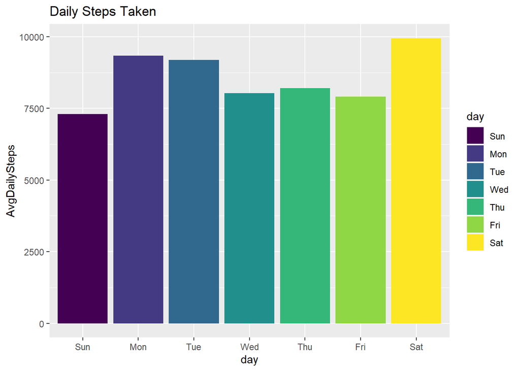

```r
ggplot(data = summarised_activity_sleep) + aes(x = day, y = AvgDailySteps, fill = day) + geom_bar(stat = "identity") + labs(title = "Daily Steps Taken")
```

We can see that most people are active on Saturday and least active on Sunday.

### Which days are participants sleeping the most?

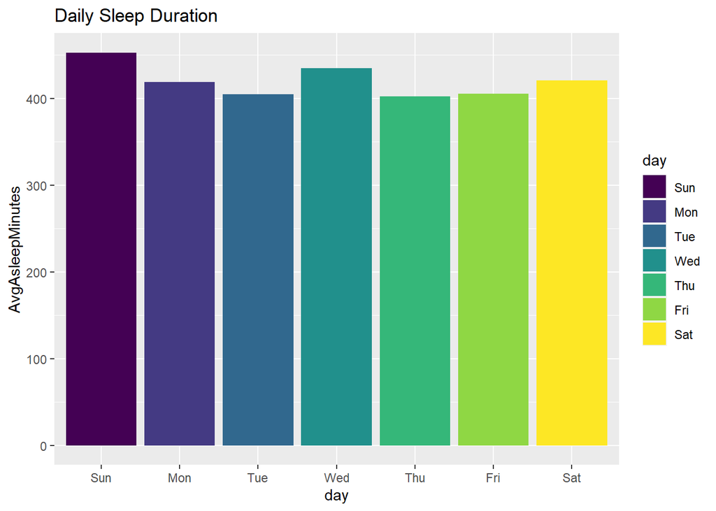

```r
ggplot(data = summarised_activity_sleep) + aes(x = day, y = AvgAsleepMinutes, fill = day) + geom_bar(stat = "identity") + labs(title = "Daily Sleep Duration")
```

Most people sleep more on Sundays.

## Summaries + Recommendations

- The average number of steps people take per day is 7638. According to CDC, people who take at least 8000 steps per day had shown a 50% reduction of risk of dying [Link to research done by CDC](https://www.nih.gov/news-events/nih-research-matters/number-steps-day-more-important-step-intensity). Therefore, Bellabeat can implement a feature where there is a section in the app that educates people on the benefits of it and also encouraging their users to at take at least 8000 steps per day.
- As the majority of users are under the lightly active category, Bellabeat can have a progression system where users have to reach a certain number of steps or certain number of workouts in order to collect points. Perhaps when Bellabeat has the funds or capacity to allow users to change the points collected into either gift cards, exercise classes or goods. This progression system can not only motivate users but also encourage them to be more active.
- We see that when people are less active, they tend to have lesser sleep. Therefore, to improve one’s quality sleep, a feature that can be implemented into the app is that users can enter their desired sleep time and awake time; then the app will calculate the hours and recommend a sleep time that is suitable depending on their sleep schedule. An app notification can also be sent out whenever no activity has been detected for a period of time that is considered sedentary.
- For people who are or might be trying to lose weight, articles such as healthy food recipes and exercise videos can be recommended to users based on their preferences.
- For users that are active on Saturday, recommendations can be sent to them on other workouts or different intensities workout or jogs. For those who are least active especially on Sunday, Bellabeat can recommend challenging workout or activity and giving double points to targeted people to encourage them to be more active.